# td4_aymericNoel.R

Aymeric-PC

Wed Oct 16 11:09:45 2019

# TD4 AYMERIC NOEL

## question 1

```r
dataset <- read.csv('http://www.mghassany.com/MLcourse/datasets/Social_Network_Ads.csv')


str(dataset)
```

```
## 'data.frame':    400 obs. of  5 variables:
##  $ User.ID        : int  15624510 15810944 15668575 15603246 15804002 15728773 15598044 15694829 15600575 15727311 ...
##  $ Gender         : Factor w/ 2 levels "Female","Male": 2 2 1 1 2 2 1 1 2 1 ...
##  $ Age            : num  19 35 26 27 19 27 27 32 25 35 ...
##  $ EstimatedSalary: num  19000 20000 43000 57000 76000 58000 84000 150000 33000 65000 ...
##  $ Purchased      : int  0 0 0 0 0 0 0 1 0 0 ...
```

```r
summary(dataset)
```

```
##     User.ID            Gender         Age        EstimatedSalary
##  Min.   :15566689   Female:204   Min.   :18.00   Min.   : 15000
##  1st Qu.:15626764   Male  :196   1st Qu.:29.75   1st Qu.: 43000
##  Median :15694342                Median :37.00   Median : 70000
##  Mean   :15691540                Mean   :37.66   Mean   : 69743
##  3rd Qu.:15750363                3rd Qu.:46.00   3rd Qu.: 88000
##  Max.   :15815236                Max.   :60.00   Max.   :150000
##    Purchased
##  Min.   :0.0000
##  1st Qu.:0.0000
##  Median :0.0000
##  Mean   :0.3575
##  3rd Qu.:1.0000
##  Max.   :1.0000
```

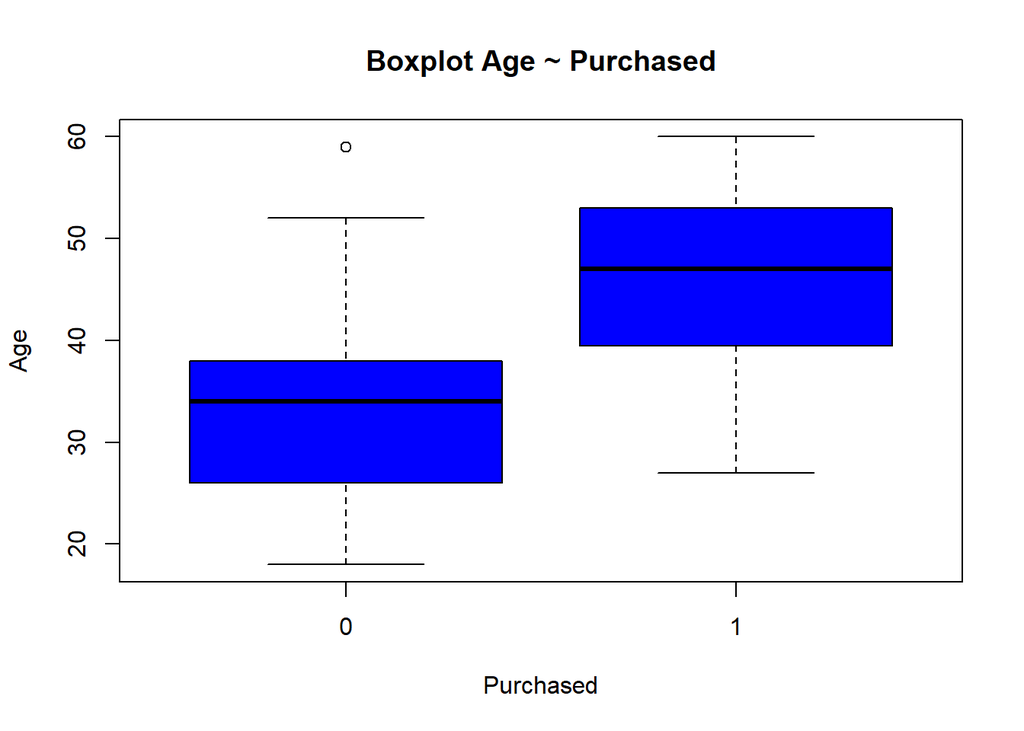

```r
boxplot(Age ~ Purchased, data=dataset, col = "blue", main="Boxplot Age ~ Purchased",ylab="Age",xlab="Purchased")
```

we can see that we are more purchased when we are older

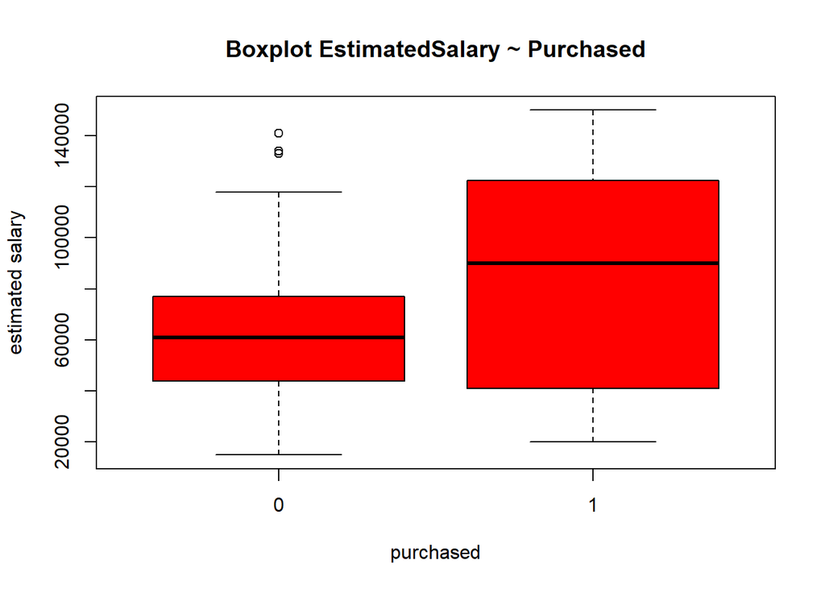

```r
boxplot(EstimatedSalary ~ Purchased, data=dataset,col = "red", main="Boxplot EstimatedSalary ~ Purchased",ylab="estimated salary",xlab="purchased")
```

more we have a big salary, more we have a chance to purchase

```r
summary(aov(EstimatedSalary ~Purchased, data=dataset))
```

```
##              Df    Sum Sq   Mean Sq F value   Pr(>F)
## Purchased     1 6.082e+10 6.082e+10   60.05 7.77e-14 ***
## Residuals   398 4.031e+11 1.013e+09
## ---
## Signif. codes:  0 '***' 0.001 '**' 0.01 '*' 0.05 '.' 0.1 ' ' 1
```

p value is <<0.01 so the variables are dependents

```r
summary(aov(Age ~Purchased, data=dataset))
```

```
##              Df Sum Sq Mean Sq F value Pr(>F)
## Purchased     1  16988   16988   251.7 <2e-16 ***
## Residuals   398  26858      67
## ---
## Signif. codes:  0 '***' 0.001 '**' 0.01 '*' 0.05 '.' 0.1 ' ' 1
```

p value is <<0.01 so the variables are dependents

```r
table(dataset$Gender,dataset$Purchased)
```

```
##
##            0   1
##   Female 127  77
##   Male   130  66
```

so the female makes more purchase because female~1=77 and male~1=66

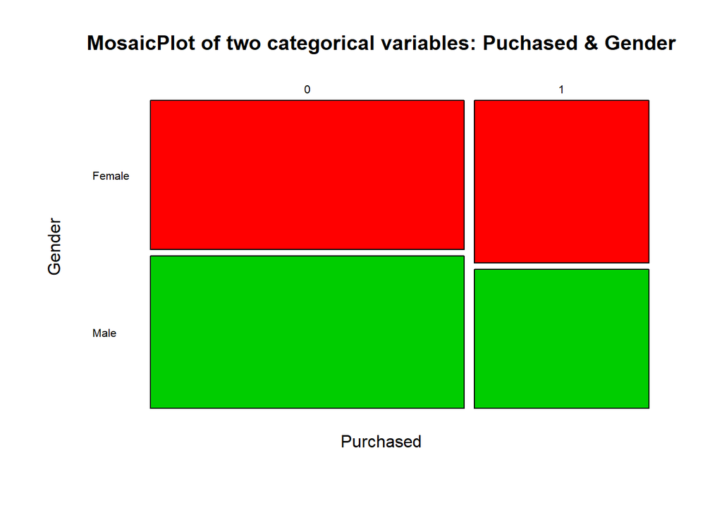

```r
mosaicplot(~ Purchased + Gender, data=dataset,
           main = "MosaicPlot of two categorical variables: Puchased & Gender",
           color = 2:3, las = 1)
```

So there isn’t correlations between gender and purchased

```r
chisq.test(dataset$Purchased, dataset$Gender)
```

```
##
##  Pearson's Chi-squared test with Yates' continuity correction
##
## data:  dataset$Purchased and dataset$Gender
## X-squared = 0.55509, df = 1, p-value = 0.4562
```

p value is >0.4 so there purchaed and gender are independent

```r
dataset = dataset[3:5]
str(dataset)
```

```
## 'data.frame':    400 obs. of  3 variables:
##  $ Age            : num  19 35 26 27 19 27 27 32 25 35 ...
##  $ EstimatedSalary: num  19000 20000 43000 57000 76000 58000 84000 150000 33000 65000 ...
##  $ Purchased      : int  0 0 0 0 0 0 0 1 0 0 ...
```

```r
library(caTools)
set.seed(700173)
split = sample.split(dataset$Purchased, SplitRatio = 0.75)
training_set = subset(dataset, split == TRUE)
test_set = subset(dataset, split == FALSE)


training_set[-3] <- scale(training_set[-3])
test_set[-3] <- scale(test_set[-3])
```

logistic regression

```r
classifier.logreg <- glm(Purchased ~ Age + EstimatedSalary , family = binomial, data=training_set)
classifier.logreg
```

```
##
## Call:  glm(formula = Purchased ~ Age + EstimatedSalary, family = binomial,
##     data = training_set)
##
## Coefficients:
##     (Intercept)              Age  EstimatedSalary
##          -1.218            2.713            1.380
##
## Degrees of Freedom: 299 Total (i.e. Null);  297 Residual
## Null Deviance:       390.9
## Residual Deviance: 197.7     AIC: 203.7
```

```r
summary(classifier.logreg)
```

```
##
## Call:
## glm(formula = Purchased ~ Age + EstimatedSalary, family = binomial,
##     data = training_set)
##
## Deviance Residuals:
##     Min       1Q   Median       3Q      Max
## -3.0701  -0.5176  -0.1202   0.3157   1.9848
##
## Coefficients:
##                 Estimate Std. Error z value Pr(>|z|)
## (Intercept)      -1.2176     0.2040  -5.969 2.39e-09 ***
## Age               2.7125     0.3528   7.690 1.48e-14 ***
## EstimatedSalary   1.3803     0.2263   6.100 1.06e-09 ***
## ---
## Signif. codes:  0 '***' 0.001 '**' 0.01 '*' 0.05 '.' 0.1 ' ' 1
##
## (Dispersion parameter for binomial family taken to be 1)
##
##     Null deviance: 390.89  on 299  degrees of freedom
## Residual deviance: 197.68  on 297  degrees of freedom
## AIC: 203.68
##
## Number of Fisher Scoring iterations: 6
```

prediction

```r
pred.glm = predict(classifier.logreg, newdata = test_set[,-3], type="response")

pred.glm_0_1 = ifelse(pred.glm >= 0.5, 1,0)

head(pred.glm)
```

```
##           2           6           9          13          15          18
## 0.030498512 0.017428781 0.003900722 0.008650415 0.004408663 0.349221532
```

```r
head(pred.glm_0_1)
```

```
##  2  6  9 13 15 18
##  0  0  0  0  0  0
```

confusion matrix

```r
cm = table(pred.glm_0_1, test_set[,3])
cm
```

```
##
## pred.glm_0_1  0  1
##            0 55 10
##            1  9 26
```

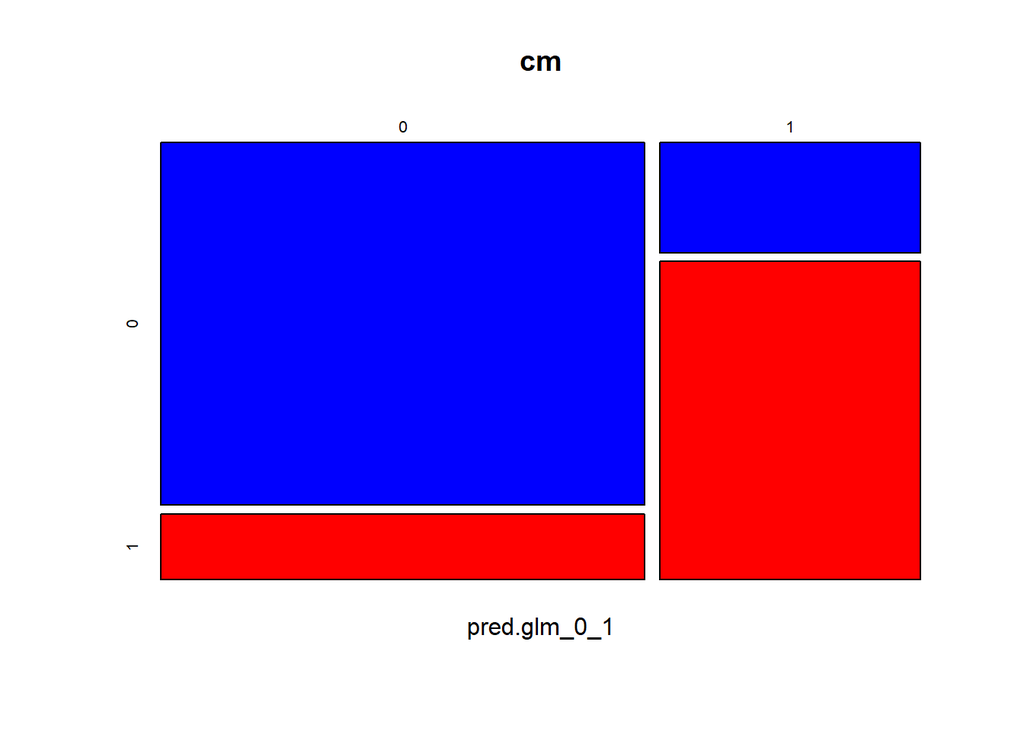

```r
mosaicplot(cm,col=sample(1:8,2))
```

ROC

```r
require(ROCR)
score <- prediction(pred.glm,test_set[,3]) # we use the predicted probabilities not the 0 or 1
performance(score,"auc") # y.values
```

```
## An object of class "performance"
## Slot "x.name":
## [1] "None"
##
## Slot "y.name":
## [1] "Area under the ROC curve"
##
## Slot "alpha.name":
## [1] "none"
##
## Slot "x.values":
## list()
##
## Slot "y.values":
## [[1]]
## [1] 0.9153646
##
##
## Slot "alpha.values":
## list()
```

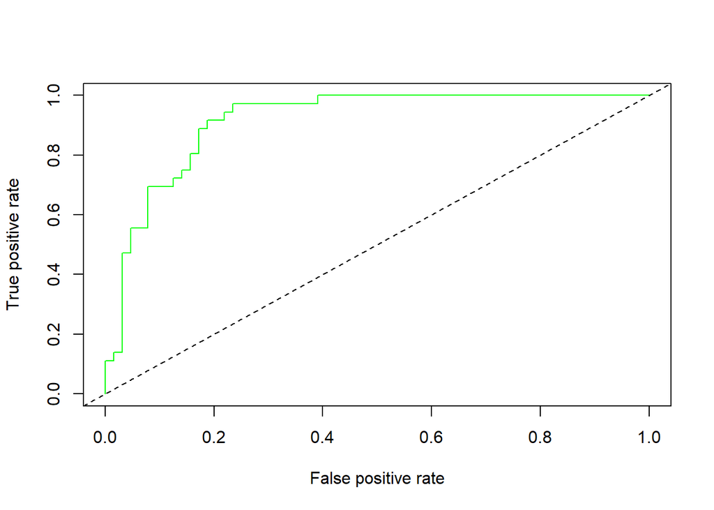

```r
plot(performance(score,"tpr","fpr"),col="green")
abline(0,1,lty=8)
```

## question 2

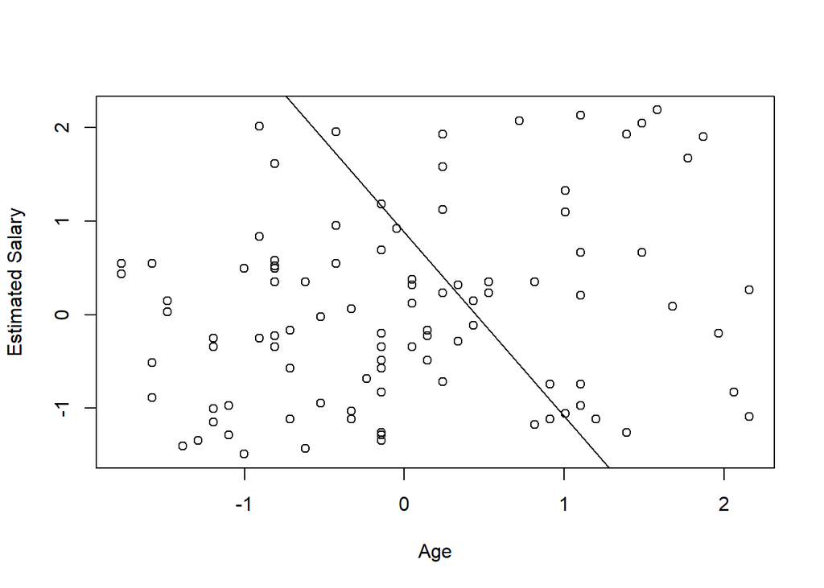

```r
intercept=-(classifier.logreg$coefficients[1]/classifier.logreg$coefficients[3])
slope=-(classifier.logreg$coefficients[2]/classifier.logreg$coefficients[3])
plot(x = test_set$Age,y=test_set$EstimatedSalary,xlab="Age",ylab="Estimated Salary")
abline(a=intercept,b=slope)
```

## question 3

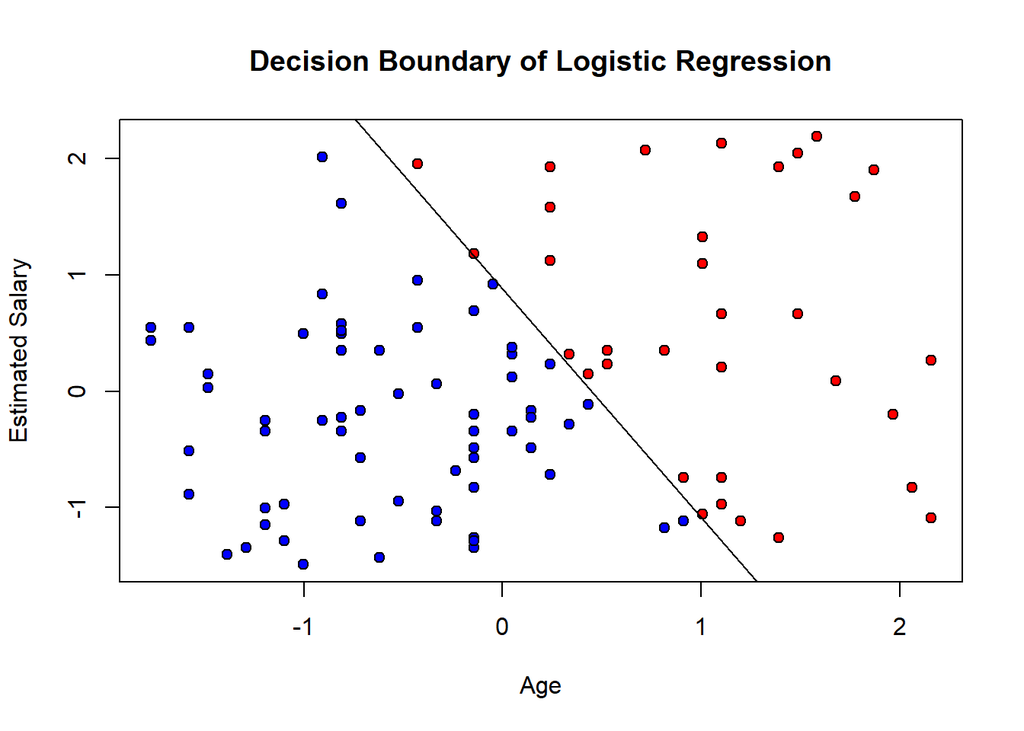

```r
plot(x = test_set$Age,y=test_set$EstimatedSalary,xlab="Age",ylab="Estimated Salary",bg=ifelse(pred.glm_0_1==1,'red','blue'),pch=21,main="Decision Boundary of Logistic Regression")
abline(a=intercept,b=slope)
```

## question 4

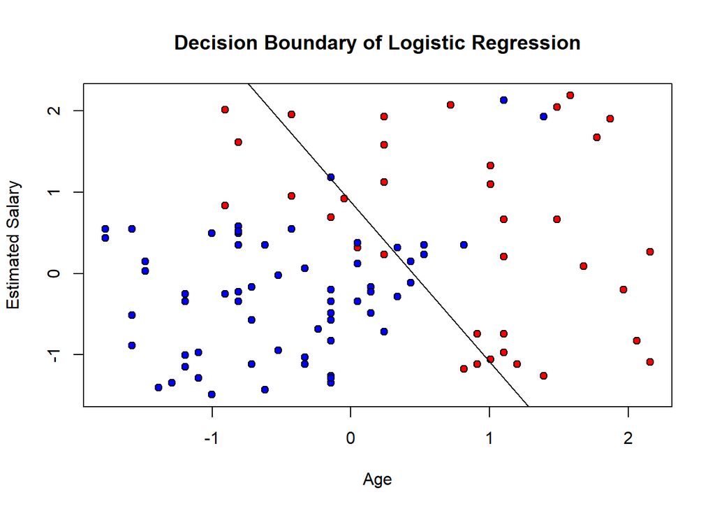

```r
plot(x = test_set$Age,y=test_set$EstimatedSalary,xlab="Age",ylab="Estimated Salary",bg=ifelse(test_set$Purchased==1,'red','blue'),pch=21,main="Decision Boundary of Logistic Regression")
abline(a=intercept,b=slope)
```

we have 9 false positive predictions (blue points among the red ones)

```r
cm[2,1]
```

```
## [1] 9
```

we see that the false positive predictions are really of 9, so all is right

## question 5

```r
library(MASS)
classifier.lda <- lda(Purchased~Age+EstimatedSalary, data=training_set)
```

## question 6

```r
classifier.lda
```

```
## Call:
## lda(Purchased ~ Age + EstimatedSalary, data = training_set)
##
## Prior probabilities of groups:
##         0         1
## 0.6433333 0.3566667
##
## Group means:
##          Age EstimatedSalary
## 0 -0.4620028      -0.2715630
## 1  0.8333322       0.4898286
##
## Coefficients of linear discriminants:
##                       LD1
## Age             1.1670515
## EstimatedSalary 0.5759121
```

we have our coefficients and our priorfor each variables

## question 7

```r
pred_lda=predict(classifier.lda,newdata =test_set)
prediction_LDA=pred_lda$class
str(predict(classifier.lda,newdata =test_set))
```

```
## List of 3
##  $ class    : Factor w/ 2 levels "0","1": 1 1 1 1 1 1 1 2 2 1 ...
##  $ posterior: num [1:100, 1:2] 0.951 0.97 0.991 0.984 0.991 ...
##   ..- attr(*, "dimnames")=List of 2
##   .. ..$ : chr [1:100] "2" "6" "9" "13" ...
##   .. ..$ : chr [1:2] "0" "1"
##  $ x        : num [1:100, 1] -0.94 -1.21 -1.84 -1.53 -1.82 ...
##   ..- attr(*, "dimnames")=List of 2
##   .. ..$ : chr [1:100] "2" "6" "9" "13" ...
##   .. ..$ : chr "LD1"
```

```r
#function predict returns vector of length 3 with posterior, x and class which we keep here
```

## question 8

```r
cmlda = table(prediction_LDA, test_set[,3])
cmlda
```

```
##
## prediction_LDA  0  1
##              0 57 11
##              1  7 25
```

```r
cm
```

```
##
## pred.glm_0_1  0  1
##            0 55 10
##            1  9 26
```

## question 9

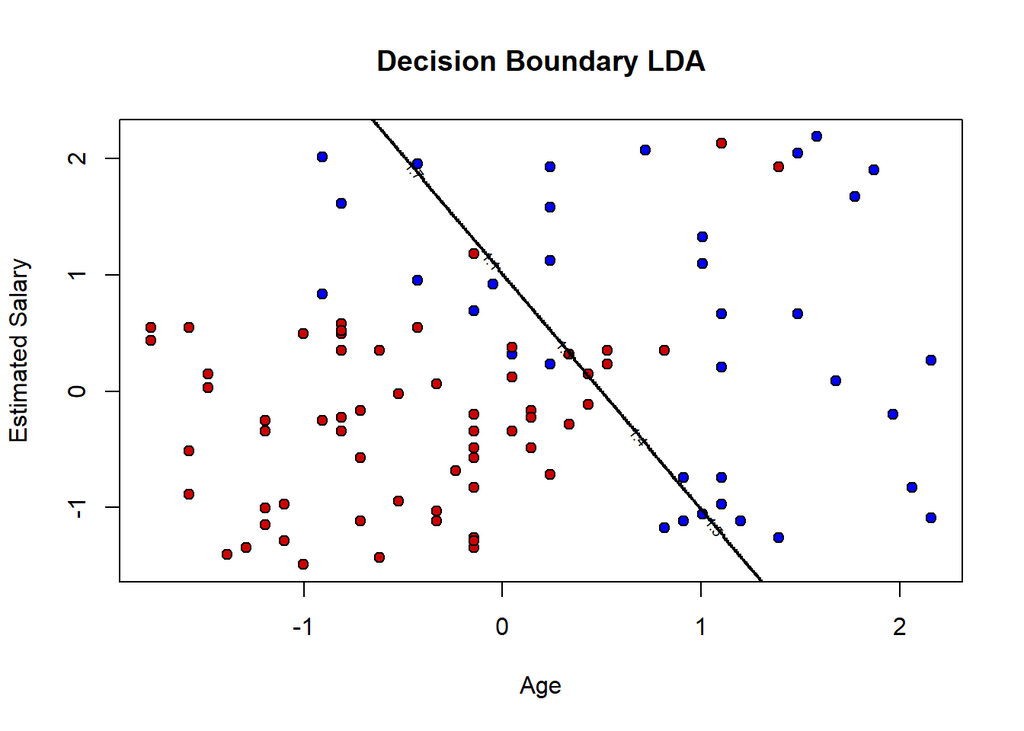

```r
X1 = seq(min(training_set[, 1]) - 1, max(training_set[, 1]) + 1, by = 0.01)
X2 = seq(min(training_set[, 2]) - 1, max(training_set[, 2]) + 1, by = 0.01)
grid_set = expand.grid(X1, X2)
colnames(grid_set) = c('Age', 'EstimatedSalary')
plot(test_set[, 1:2],
     main = 'Decision Boundary LDA',
     xlab = 'Age', ylab = 'Estimated Salary')
points(test_set[1:2], pch = 21, bg = ifelse(test_set[, 3] == 1, 'blue', 'red3'))
pred_grid = predict(classifier.lda, newdata = grid_set)$class
contour(X1, X2, matrix(as.numeric(pred_grid), length(X1), length(X2)), add = TRUE)
```

## question 10.1

```r
class0=training_set[training_set$Purchased==0,]
class1=training_set[training_set$Purchased==1,]
```

## question 10.2

```r
pi0=length(class0$Purchased)/length(training_set$Purchased)
pi1=length(class1$Purchased)/length(training_set$Purchased)
```

## question 10.3

```r
mu0=c(mean(class0$Age),mean(class0$EstimatedSalary))
mu1=c(mean(class1$Age),mean(class1$EstimatedSalary))
```

## question 10.4

```r
sigma=((length(class0$Purchased)-1)*var(class0[-3]))/(length(training_set$Purchased)-2)+((length(class1$Purchased)-1)*var(class1[-3]))/(length(training_set$Purchased)-2)

#question 10.5
#
#x=c(1,1.5)
#delta0=(t(x)*mu0)/sigma-(mu0^2)/(2*sigma)+log(pi0)
#delta1=(t(x)*mu1)/sigma-(mu1^2)/(2*sigma)+log(pi1)
#delta0=(x*(sigma^-1))*mu0-(1/2)(t(mu0)*(sigma^-1)*mu0)+log(pi0)

#delta1
#so, class 0
#

#question 10.6
#beta0=test_set*(sigma^-1)*mu0-(1/2)*t(mu0)*sigma^-1*mu0+log(pi0)
#beta1=test_set*(sigma^-1)*mu1-(1/2)*t(mu1)*sigma^-1*mu1+log(pi1)
#beta0
#beta1
```

## question 11

```r
classifier.qda <- qda(Purchased~., data = training_set)
summary(classifier.qda)
```

```
##         Length Class  Mode
## prior   2      -none- numeric
## counts  2      -none- numeric
## means   4      -none- numeric
## scaling 8      -none- numeric
## ldet    2      -none- numeric
## lev     2      -none- character
## N       1      -none- numeric
## call    3      -none- call
## terms   3      terms  call
## xlevels 0      -none- list
```

## question 12

```r
prediction.qda = predict(classifier.qda, newdata = test_set[,-3])
pred.qda = prediction.qda$class
cm.qda = table(pred.qda,test_set[,3])
cm.qda
```

```
##
## pred.qda  0  1
##        0 60  6
##        1  4 30
```

```r
accuracy=(cm.qda[1,1]+cm.qda[2,2])/sum(cm.qda) *100
accuracy
```

```
## [1] 90
```

```r
cmlda
```

```
##
## prediction_LDA  0  1
##              0 57 11
##              1  7 25
```

```r
accuracy2=(cmlda[1,1]+cmlda[2,2])/sum(cmlda) *100
accuracy2
```

```
## [1] 82
```

So resultas are better with qda method

## question 13

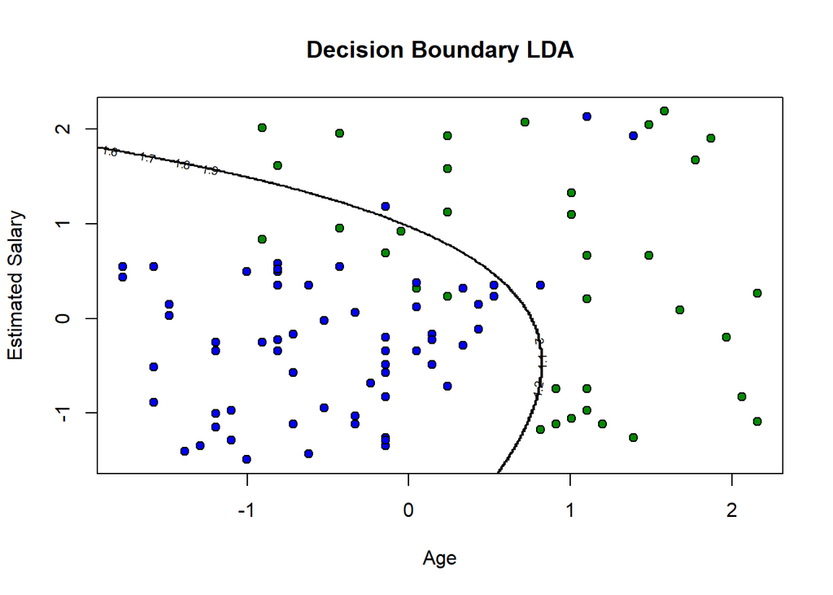

```r
X1_1 = seq(min(training_set[, 1]) - 1, max(training_set[, 1]) + 1, by = 0.01)
X2_2 = seq(min(training_set[, 2]) - 1, max(training_set[, 2]) + 1, by = 0.01)
grid_set2 = expand.grid(X1_1, X2_2)
colnames(grid_set2) = c('Age', 'EstimatedSalary')
plot(test_set[, 1:2],
     main = 'Decision Boundary LDA',
     xlab = 'Age', ylab = 'Estimated Salary')
points(test_set[1:2], pch = 21, bg = ifelse(test_set[, 3] == 1, 'green4', 'blue'))
pred_grid2 = predict(classifier.qda, newdata = grid_set)$class
contour(X1_1, X2_2, matrix(as.numeric(pred_grid2), length(X1_1), length(X2_2)), add = TRUE)
```

## question 14

```r
score.glm <- prediction(pred.glm,test_set[,3])
score.lda <- prediction(pred_lda$posterior[,2],test_set[,3])
score.qda <- prediction(prediction.qda$posterior[,2],test_set[,3])
```

we compute scores

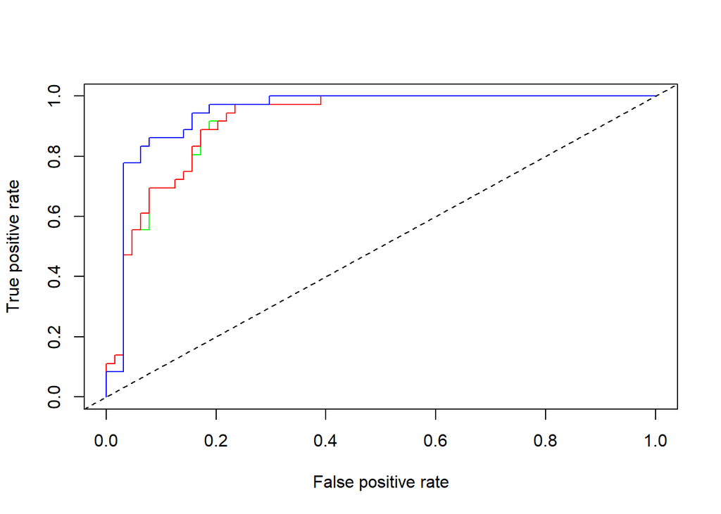

```r
plot(performance(score.glm,"tpr","fpr"),col="green")
plot(performance(score.lda,"tpr","fpr"),col="red",add=T)
plot(performance(score.qda,"tpr","fpr"),col="blue",add=T)
abline(0,1,lty=8)
```

we display all AUC values

```r
AUC.scoreglm=performance(score.glm,"auc")@y.values[[1]]
AUC.scoreglm
```

```
## [1] 0.9153646
```

```r
AUC.scorelda=performance(score.lda,"auc")@y.values[[1]]
AUC.scorelda
```

```
## [1] 0.9162326
```

```r
AUC.scoreqda=performance(score.qda,"auc")@y.values[[1]]
AUC.scoreqda
```

```
## [1] 0.9466146
```

So the best model here is the qda model, then the lda model then the logistic model